# ¿Quiénes protestan? - Trabajo Maestría

Luis Alberto Chávez

2025-06-12

# Preparando la data

```r
rm(list = ls()) # limpiar el working environment

linkADrive='https://docs.google.com/spreadsheets/d/e/2PACX-1vQoN_1tfvAClKCO6wjHLy7rGNdbZx2nuvTm99d2FzrwIoohr2rqetFfCLTErgYYTg/pub?gid=486140846&single=true&output=csv'

protestas=read.csv(linkADrive)

head(protestas)
```

```
##   UBIGEO NOM_PROV     NOM_DIST CONFLICTOS PP_Nac_Loc PP_Nom POBLACION ALTITUD
## 1  80201  ACOMAYO      ACOMAYO          0          1     SP      4523    3235
## 2  80202  ACOMAYO       ACOPIA          0          2   MRIP      3121    3724
## 3  80203  ACOMAYO         ACOS          0          1     SP      2328    3106
## 4  80204  ACOMAYO MOSOC LLACTA          0          1     SP       983    3820
## 5  80205  ACOMAYO   POMACANCHI          0          2    APP      7515    3709
## 6  80206  ACOMAYO     RONDOCAN          1          1     SP      1800    3394
##   TRANS_TOTAL TRANS_TOTAL_MILL RENTA_PER PORC_EJEC DIAS_ATRASO
## 1     5077807             5.08    467.52        NA          NA
## 2     3469203             3.47    462.37        NA          NA
## 3     2474700             2.47    442.53        NA          NA
## 4     2418484             2.42   1026.44        NA          NA
## 5     8357551             8.36    463.01      79.2         870
## 6     1686511             1.69    390.64        NA          NA
```

```r
str(protestas)
```

```
## 'data.frame':    116 obs. of  13 variables:
##  $ UBIGEO          : int  80201 80202 80203 80204 80205 80206 80207 80302 80301 80303 ...
##  $ NOM_PROV        : chr  "ACOMAYO" "ACOMAYO" "ACOMAYO" "ACOMAYO" ...
##  $ NOM_DIST        : chr  "ACOMAYO" "ACOPIA" "ACOS" "MOSOC LLACTA" ...
##  $ CONFLICTOS      : int  0 0 0 0 0 1 0 0 14 1 ...
##  $ PP_Nac_Loc      : int  1 2 1 1 2 1 2 2 2 2 ...
##  $ PP_Nom          : chr  "SP" "MRIP" "SP" "SP" ...
##  $ POBLACION       : int  4523 3121 2328 983 7515 1800 3362 7900 26916 2854 ...
##  $ ALTITUD         : int  3235 3724 3106 3820 3709 3394 3788 3479 2800 3424 ...
##  $ TRANS_TOTAL     : int  5077807 3469203 2474700 2418484 8357551 1686511 4783121 10110480 24131530 1698066 ...
##  $ TRANS_TOTAL_MILL: num  5.08 3.47 2.47 2.42 8.36 ...
##  $ RENTA_PER       : num  468 462 443 1026 463 ...
##  $ PORC_EJEC       : num  NA NA NA NA 79.2 NA NA 56.2 NA NA ...
##  $ DIAS_ATRASO     : int  NA NA NA NA 870 NA NA 841 NA NA ...
```

Le damos formato a nuestras variables

```r
protestas$PP_Nac_Loc = as.factor(protestas$PP_Nac_Loc) #lo convertimos a una variable categórica ya que R lo puede leer mal
protestas$PP_Nom = as.factor(protestas$PP_Nom)  #también lo convertimos a una variable categórica
```

# **Exploración Univariada de nuestra variable dependiente: Conflictos (contando a Cusco)**

```r
summary(protestas$CONFLICTOS)
```

```
##    Min. 1st Qu.  Median    Mean 3rd Qu.    Max.
##    0.00    0.00    1.00    7.44    5.00  294.00
```

Vemos los estadígrafos:

```r
library(DescTools)
allStats=c(summary(protestas$CONFLICTOS),
  sd=sd(protestas$CONFLICTOS), # variabilidad (en relacion a la media)
  skew=Skew(protestas$CONFLICTOS), # asimetria (positiva o negativa)
  kurt=Kurt(protestas$CONFLICTOS), # concentración (enpinada / aplanada)
  cv=CoefVar(protestas$CONFLICTOS)) # variabilidad (mayor o menor que uno)
allStats
```

```
##       Min.    1st Qu.     Median       Mean    3rd Qu.       Max.         sd
##   0.000000   0.000000   1.000000   7.439655   5.000000 294.000000  28.709728
##       skew       kurt         cv
##   8.698648  82.793186   3.859013
```

Empleando un histograma:

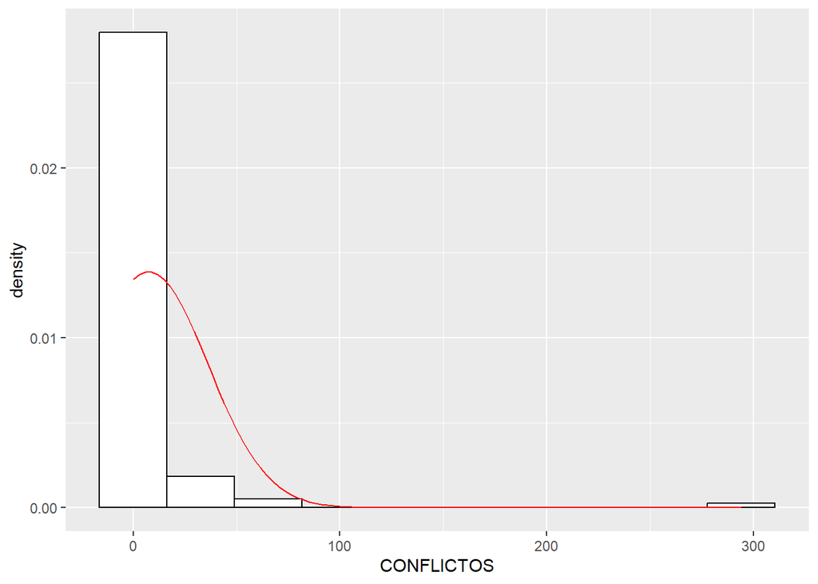

```r
library(ggplot2)
base=ggplot(data=protestas,
            aes(x=CONFLICTOS))
histogram= base + geom_histogram(aes(y = after_stat(density)),
                 colour = 1, fill = "white",bins=10) +
    stat_function(fun = dnorm,
                  args = list(mean = allStats['Mean'],
                              sd = allStats['sd']),col='red')

histogram
```

Y en un boxplot:

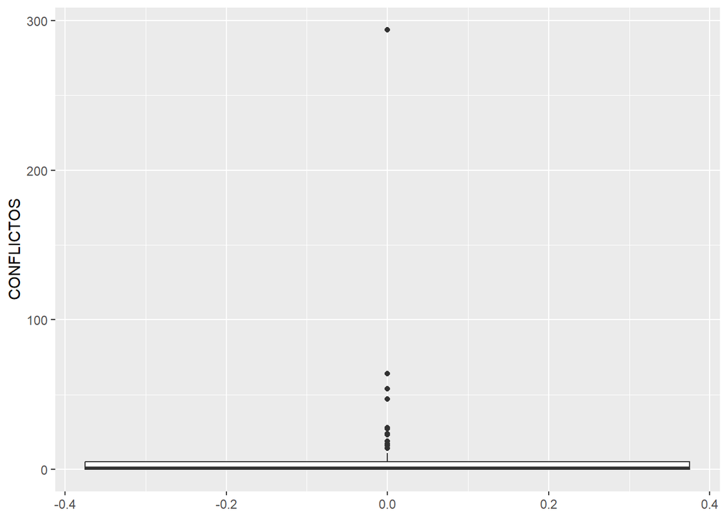

```r
base=ggplot(data=protestas,
            aes(y=CONFLICTOS))
boxplot=base + geom_boxplot()

boxplot
```

```r
library(dplyr)
protestas %>%
  arrange(desc(CONFLICTOS)) %>%
  slice_head(n = 5)
```

```
##   UBIGEO      NOM_PROV   NOM_DIST CONFLICTOS PP_Nac_Loc PP_Nom POBLACION
## 1  80101         CUSCO      CUSCO        294          2   MRIP    119148
## 2  80801       ESPINAR    ESPINAR         64          2     AA     40781
## 3  80601       CANCHIS    SICUANI         54          2   MRIP     65864
## 4  80901 LA CONVENCION  SANTA ANA         47          1    APP     29456
## 5  80702  CHUMBIVILCAS CAPACMARCA         28          1     SP      4064
##   ALTITUD TRANS_TOTAL TRANS_TOTAL_MILL RENTA_PER PORC_EJEC DIAS_ATRASO
## 1    3439    47619888            47.62    166.30        NA          NA
## 2    3976    27802717            27.80    283.34        NA          NA
## 3    3593    43903355            43.90    277.32        NA          NA
## 4    1086    69821925            69.82    987.15        NA          NA
## 5    3563     4617367             4.62    473.05        NA          NA
```

Podemos observar como Cusco concentra un mayor número de conflictos. Esto se debe a las limitaciones en la creación de la base de datos. Es por ello que, por motivos metodológicos, vamos a obviar al distrito de Cusco y el resto de filas que cuenten con valores vacíos para nuestros cálculos.

Borramos los NAs, y nos percatamos que nos quedan 81 observaciones/distritos. Nuestro trabajo aún sigue en pie!

```r
protestas <- protestas[complete.cases(protestas), ]
```

# **Exploración Univariada de nuestra variable dependiente: Conflictos (sin Cusco, ni NA’s)**

Aquí podemos ver el valor mínimo, máximo, los cuartiles.

```r
summary(protestas$CONFLICTOS)
```

```
##    Min. 1st Qu.  Median    Mean 3rd Qu.    Max.
##   0.000   0.000   1.000   3.074   4.000  27.000
```

Pero nos faltan alguns estadígrafos:

```r
library(DescTools)
allStats=c(summary(protestas$CONFLICTOS),
  sd=sd(protestas$CONFLICTOS), # variabilidad (en relacion a la media)
  skew=Skew(protestas$CONFLICTOS), # asimetria (positiva o negativa)
  kurt=Kurt(protestas$CONFLICTOS), # concentración (enpinada / aplanada)
  cv=CoefVar(protestas$CONFLICTOS)) # variabilidad (mayor o menor que uno)
allStats
```

```
##      Min.   1st Qu.    Median      Mean   3rd Qu.      Max.        sd      skew
##  0.000000  0.000000  1.000000  3.074074  4.000000 27.000000  5.212432  2.536538
##      kurt        cv
##  6.924679  1.695610
```

Podemos verlo en el siguiente histograma:

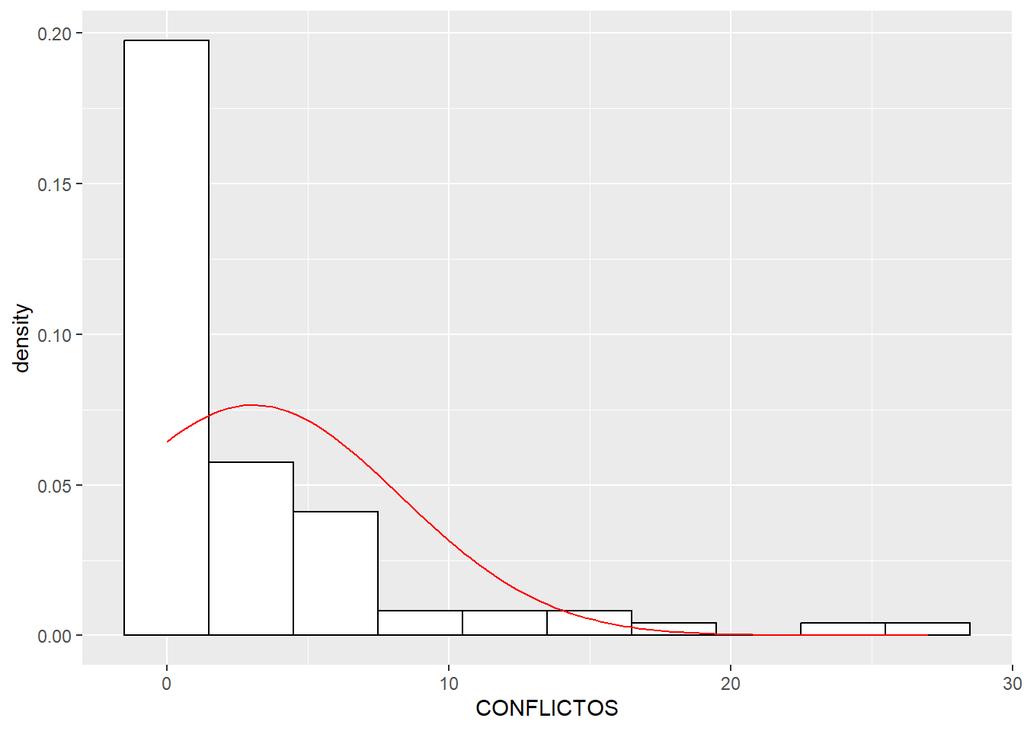

```r
library(ggplot2)

base=ggplot(data=protestas,
            aes(x=CONFLICTOS))
histogram= base + geom_histogram(aes(y = after_stat(density)),
                 colour = 1, fill = "white",bins=10) +
    stat_function(fun = dnorm,
                  args = list(mean = allStats['Mean'],
                              sd = allStats['sd']),col='red')

histogram
```

Podemos verlo en un boxplot:

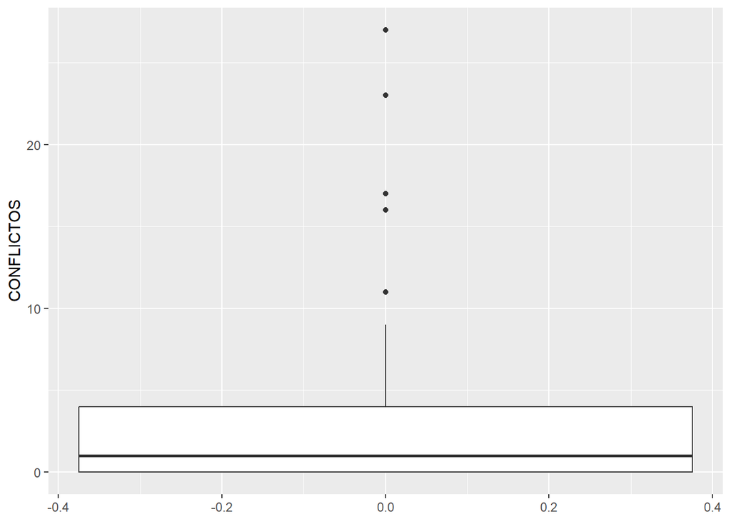

```r
base=ggplot(data=protestas,
            aes(y=CONFLICTOS))
boxplot=base + geom_boxplot()

boxplot
```

Observamos como la data mejora, así que vamos por un buen camino.

Podemos identificar a los atípicos:

```r
valuesFromBox=ggplot_build(boxplot)$data[[1]]
valuesFromBox
```

```
##   ymin lower middle upper ymax                   outliers notchupper notchlower
## 1    0     0      1     4    9 16, 27, 23, 17, 11, 11, 16   1.702222  0.2977778
##   x flipped_aes PANEL group ymin_final ymax_final   xmin  xmax xid newx
## 1 0       FALSE     1    -1          0         27 -0.375 0.375   1    0
##   new_width weight colour  fill alpha shape linetype linewidth
## 1      0.75      1 grey20 white    NA    19    solid       0.5
```

```r
outliersLocales=valuesFromBox$outliers[[1]]
outliersLocales
```

```
## [1] 16 27 23 17 11 11 16
```

Podemos calcular los outliers usando los máximos y mínimos teóricos:

```r
valuesFromBox[c('ymin','ymax')]
```

```
##   ymin ymax
## 1    0    9
```

**Entonces, los valores que excedan 9 serán considerados atípicos: Tabla Atípicos**

```r
protestas[protestas$CONFLICTOS>9,]
```

```
##     UBIGEO      NOM_PROV      NOM_DIST CONFLICTOS PP_Nac_Loc PP_Nom POBLACION
## 43   80704  CHUMBIVILCAS   COLQUEMARCA         16          1     PL      6923
## 48   80708  CHUMBIVILCAS       VELILLE         27          1     PL      8587
## 56   80108         CUSCO       WANCHAQ         23          1    PFE     61530
## 59   80803       ESPINAR     COPORAQUE         17          1     SP      8688
## 76   80907 LA CONVENCION      QUIMBIRI         11          2   MRIP     14056
## 96   81106   PAUCARTAMBO     KOSÑIPATA         11          1     SP      4924
## 114  81306      URUBAMBA OLLANTAYTAMBO         16          1     SP     12061
##     ALTITUD TRANS_TOTAL TRANS_TOTAL_MILL RENTA_PER PORC_EJEC DIAS_ATRASO
## 43     3606     9432339             9.43    567.48      85.2         783
## 48     3766     9960410             9.96    482.60      91.0         973
## 56     3424    11035252            11.04     74.64      55.5         689
## 59     3600     8205436             8.21    394.71      70.1        1067
## 76      590   129322852           129.32   3824.54      79.5         712
## 96      544    16973835            16.97   1434.45      58.3         715
## 114    2871    18055156            18.06    622.75      83.3        1019
```

Podemos decir que las protestas se distribuyen por lo general entre 0 y 9 entre todos los distritos del departamento del Cusco. Asimismo, a través de la mediana, notamos que la mitad de los distritos sostiene 1 conflicto en el año 2023. Por otro lado, los distritos destacados son 7.

**Podemos agrupar las protestas por provincias:**

```r
library(dplyr)
protestas_provincias <- protestas %>%
  group_by(NOM_PROV) %>%
  summarise(total_conflictos = sum(CONFLICTOS, na.rm = TRUE))

protestas_provincias
```

```
## # A tibble: 13 × 2
##    NOM_PROV      total_conflictos
##    <chr>                    <int>
##  1 ACOMAYO                      0
##  2 ANTA                         1
##  3 CALCA                        4
##  4 CANAS                        0
##  5 CANCHIS                     15
##  6 CHUMBIVILCAS                70
##  7 CUSCO                       46
##  8 ESPINAR                     27
##  9 LA CONVENCION               38
## 10 PARURO                       1
## 11 PAUCARTAMBO                 11
## 12 QUISPICANCHI                13
## 13 URUBAMBA                    23
```

# Regresión Poisson

En nuestro caso, lo ideal resulta ser correr una regresión Poisson, ya que nuestra variable dependiente se trata de un conteo, el conteo de los conflictos a nivel distrital.

Nuestra hipótesis destaca que el número de conflictos en los distritos del Cusco, se encuentran afectados por el tipo de partido (ya sea nacionalista o local), la transferencia total por canon gasífero en millones, la renta per cápita, la altitud, el porcentaje de ejecución presupuestal y el número de días de atraso en obras públicas.

```r
library("modelsummary")
hipo = formula(CONFLICTOS ~ PP_Nac_Loc + TRANS_TOTAL_MILL + RENTA_PER + ALTITUD + PORC_EJEC + DIAS_ATRASO)

rp = glm(hipo, data = protestas,
         offset = log(POBLACION),   # variable de control: población
         family = poisson(link = "log"))

modelo = list('Poisson asegurado (I)' = rp)

modelsummary(modelo,
             title = "Regresión Poisson",
             stars = TRUE,
             output = "kableExtra")
```

Regresión Poisson

|  | &nbsp;Poisson asegurado (I) |
| --- | --- |
| (Intercept) | -7.668*** |
|  | (0.502) |
| PP_Nac_Loc2 | -0.934*** |
|  | (0.188) |
| TRANS_TOTAL_MILL | -0.019*** |
|  | (0.003) |
| RENTA_PER | 0.000*** |
|  | (0.000) |
| ALTITUD | 0.000 |
|  | (0.000) |
| PORC_EJEC | -0.006 |
|  | (0.005) |
| DIAS_ATRASO | 0.001* |
|  | (0.000) |
| Num.Obs. | 81 |
| AIC | 578.2 |
| BIC | 595.0 |
| Log.Lik. | -282.108 |
| F | 16.994 |
| RMSE | 4.72 |

+ p < 0.1, * p < 0.05, ** p < 0.01, *** p < 0.001

Si bien esta primera tabla nos da un vistazo inicial, es necesario exponenciar los valores.

```r
formatoNum <- function(x) format(x, digits = 4, scientific = FALSE)

modelsummary(modelo,
             fmt=formatoNum, # uso mi formula
             exponentiate = T, # exponenciar!!!!!
             statistic = 'conf.int',
             title = "Regresión Poisson - coeficientes exponenciados",
             stars = TRUE,
             output = "kableExtra")
```

Regresión Poisson - coeficientes exponenciados

|  | &nbsp;Poisson asegurado (I) |
| --- | --- |
| (Intercept) | 0.0004675*** |
|  | [0.0001716, 0.001228] |
| PP_Nac_Loc2 | 0.3928856*** |
|  | [0.2683768, 0.561627] |
| TRANS_TOTAL_MILL | 0.9808565*** |
|  | [0.9746631, 0.986808] |
| RENTA_PER | 1.0003648*** |
|  | [1.0002515, 1.000483] |
| ALTITUD | 0.9999614 |
|  | [0.9998125, 1.000119] |
| PORC_EJEC | 0.9944969 |
|  | [0.9853814, 1.003962] |
| DIAS_ATRASO | 1.0006581* |
|  | [1.0000175, 1.001289] |
| Num.Obs. | 81 |
| AIC | 578.2 |
| BIC | 595.0 |
| Log.Lik. | -282.108 |
| F | 16.994 |
| RMSE | 4.72 |

+ p < 0.1, * p < 0.05, ** p < 0.01, *** p < 0.001

## Equidispersión

Sin embargo, uno de los supuestos de la regresión Poisson señala que tanto la media y la varianza deben ser iguales. Para conocer si nuestra regresión cumple esa condición corremos la siguiente prueba:

```r
library(magrittr)
library(kableExtra)
overdispersion=AER::dispersiontest(rp,alternative='greater')$ p.value<0.05
underdispersion=AER::dispersiontest(rp,alternative='less')$ p.value<0.05
# tabla
testResult=as.data.frame(rbind(overdispersion,underdispersion))
names(testResult)='Es probable?'
testResult%>%kable(caption = "Test de Equidispersión")%>%kableExtra::kable_styling()
```

Test de Equidispersión

|  | Es probable? |
| --- | --- |
| overdispersion | TRUE |
| underdispersion | FALSE |

Hemos hallado la presencia de sobredispersión, por lo que debemos correr una regresión Quasi Poisson y una Binomial Negativa

### Quasi Poisson

Útil para la sobredispersión y subdispersión.

```r
rqp = glm(hipo, data = protestas,
          offset = log(POBLACION),
          family = quasipoisson(link="log"))

modelsummary(rqp,
             title = "Regresión QuasiPoisson",
             stars = TRUE,
             output = "kableExtra")
```

Regresión QuasiPoisson

|  | &nbsp;(1) |
| --- | --- |
| (Intercept) | -7.668*** |
|  | (1.480) |
| PP_Nac_Loc2 | -0.934+ |
|  | (0.554) |
| TRANS_TOTAL_MILL | -0.019* |
|  | (0.009) |
| RENTA_PER | 0.000* |
|  | (0.000) |
| ALTITUD | 0.000 |
|  | (0.000) |
| PORC_EJEC | -0.006 |
|  | (0.014) |
| DIAS_ATRASO | 0.001 |
|  | (0.001) |
| Num.Obs. | 81 |
| F | 1.954 |
| RMSE | 4.72 |

+ p < 0.1, * p < 0.05, ** p < 0.01, *** p < 0.001

### Binomial Negativa

Útil solo para la sobredispersión

```r
library(MASS)
hipo_bn = formula(CONFLICTOS ~ PP_Nac_Loc + TRANS_TOTAL_MILL + RENTA_PER + ALTITUD + PORC_EJEC + DIAS_ATRASO + offset(log(POBLACION)))

rbn = glm.nb(hipo_bn, data = protestas)

modelsummary(rbn,
             title = "Regresión BinomialNegativa",
             stars = TRUE,
             output = "kableExtra")
```

Regresión BinomialNegativa

|  | &nbsp;(1) |
| --- | --- |
| (Intercept) | -7.721*** |
|  | (1.378) |
| PP_Nac_Loc2 | -0.664 |
|  | (0.441) |
| TRANS_TOTAL_MILL | -0.008 |
|  | (0.008) |
| RENTA_PER | 0.000 |
|  | (0.000) |
| ALTITUD | 0.000 |
|  | (0.000) |
| PORC_EJEC | -0.002 |
|  | (0.013) |
| DIAS_ATRASO | 0.000 |
|  | (0.001) |
| Num.Obs. | 81 |
| AIC | 347.3 |
| BIC | 366.5 |
| Log.Lik. | -165.656 |
| F | 0.696 |
| RMSE | 5.80 |

+ p < 0.1, * p < 0.05, ** p < 0.01, *** p < 0.001

## Vemos nuestras regresiones

```r
todos_modelos = list('Poisson'= rp,
                     'Quasi Poisson'= rqp,
                     'Binomial Negativa'= rbn)

modelsummary(todos_modelos, fmt=formatoNum,
             exponentiate = T,
             statistic = 'conf.int',
             title = "EXP de las Regresiones",
             stars = TRUE,
             output = "kableExtra")
```

EXP de las Regresiones

|  | Poisson | Quasi Poisson | Binomial Negativa |
| --- | --- | --- | --- |
| (Intercept) | 0.0004675*** | 0.0004675*** | 0.0004434*** |
|  | [0.0001716, 0.001228] | [0.00002161, 0.007372] | [0.00003196, 0.007732] |
| PP_Nac_Loc2 | 0.3928856*** | 0.3928856+ | 0.5145375 |
|  | [0.2683768, 0.561627] | [0.11684771, 1.068867] | [0.20664015, 1.329637] |
| TRANS_TOTAL_MILL | 0.9808565*** | 0.9808565* | 0.9921068 |
|  | [0.9746631, 0.986808] | [0.96196987, 0.997736] | [0.97564008, 1.013426] |
| RENTA_PER | 1.0003648*** | 1.0003648* | 1.0001606 |
|  | [1.0002515, 1.000483] | [1.00004032, 1.000731] | [0.99975563, 1.000569] |
| ALTITUD | 0.9999614 | 0.9999614 | 0.9999918 |
|  | [0.9998125, 1.000119] | [0.99954148, 1.000454] | [0.99958466, 1.000358] |
| PORC_EJEC | 0.9944969 | 0.9944969 | 0.9977632 |
|  | [0.9853814, 1.003962] | [0.96830450, 1.023753] | [0.96881051, 1.026263] |
| DIAS_ATRASO | 1.0006581* | 1.0006581 | 1.0003166 |
|  | [1.0000175, 1.001289] | [0.99874360, 1.002492] | [0.99877602, 1.001894] |
| Num.Obs. | 81 | 81 | 81 |
| AIC | 578.2 |  | 347.3 |
| BIC | 595.0 |  | 366.5 |
| Log.Lik. | -282.108 |  | -165.656 |
| F | 16.994 | 1.954 | 0.696 |
| RMSE | 4.72 | 4.72 | 5.80 |

+ p < 0.1, * p < 0.05, ** p < 0.01, *** p < 0.001

# Comparando modelos

```r
# poisson case
performance::check_overdispersion(rp)
```

```
## # Overdispersion test
##
##        dispersion ratio =   8.698
##   Pearson's Chi-Squared = 643.645
##                 p-value = < 0.001
```

```
## Overdispersion detected.
```

```r
# quasipoisson case
performance::check_overdispersion(rqp)
```

```
## # Overdispersion test
##
##        dispersion ratio =   8.698
##   Pearson's Chi-Squared = 643.645
##                 p-value = < 0.001
```

```
## Overdispersion detected.
```

```r
# negative binomial case
library(DHARMa)
performance::check_overdispersion(rbn)
```

```
## # Overdispersion test
##
##  dispersion ratio = 0.376
##           p-value = 0.464
```

```
## No overdispersion detected.
```

Por el momento vemos que la mejor regresión resulta ser la Binomial Negativa, ya que elimina la sobredispersión.

Asimismo, como no son modelos anidados, usamos la tabla anova con cuidado, pidiendo un test chi-cuadrado, para comparar los modelos:

```r
anova(rp,rqp,rbn,test = "Chisq") %>%
kable(caption = "Tabla ANOVA para comparar modelos")%>%kableExtra::kable_styling(full_width = FALSE)
```

Tabla ANOVA para comparar modelos

| Resid. Df | Resid. Dev | Df | Deviance | Pr(>Chi) |
| --- | --- | --- | --- | --- |
| 74 | 424.10534 | NA | NA | NA |
| 74 | 424.10534 | 0 | 0.0000 | NA |
| 74 | 79.48912 | 0 | 344.6162 | NA |

Aquí nos fijamos en el Resid.Dev, si decae de una regresión a otra suele ser mejor la última opción.

Podemos emplear otra prueba:

```r
lmtest::lrtest(rp,rbn)%>%
kable(caption = "loglikelihood ratio test")%>%kableExtra::kable_styling(full_width = FALSE)
```

loglikelihood ratio test

| #Df | LogLik | Df | Chisq | Pr(>Chisq) |
| --- | --- | --- | --- | --- |
| 7 | -282.1084 | NA | NA | NA |
| 8 | -165.6562 | 1 | 232.9045 | 0 |

Aquí nos fijamos en el LogLik, si el número se acerca más al 0 de una regresión a otra, suele ser mejor.

# **Nuestra tabla de interés**

Por todos los resultados, podemos quedarnos con la regresión Binomial Negativa para comprender los resultados:

```r
modelo_bn = list('Binomial Negativa asegurado (I)' = rbn)

formatoNum <- function(x) format(x, digits = 4, scientific = FALSE)

modelsummary(modelo_bn,
             fmt=formatoNum, # uso mi formula
             exponentiate = T, # exponenciar!!!!!
             statistic = 'conf.int',
             title = "Regresión Binomial Negativa - coeficientes exponenciados",
             stars = TRUE,
             output = "kableExtra")
```

Regresión Binomial Negativa - coeficientes exponenciados

|  | &nbsp;Binomial Negativa asegurado (I) |
| --- | --- |
| (Intercept) | 0.0004434*** |
|  | [0.00003196, 0.007732] |
| PP_Nac_Loc2 | 0.5145375 |
|  | [0.20664015, 1.329637] |
| TRANS_TOTAL_MILL | 0.9921068 |
|  | [0.97564008, 1.013426] |
| RENTA_PER | 1.0001606 |
|  | [0.99975563, 1.000569] |
| ALTITUD | 0.9999918 |
|  | [0.99958466, 1.000358] |
| PORC_EJEC | 0.9977632 |
|  | [0.96881051, 1.026263] |
| DIAS_ATRASO | 1.0003166 |
|  | [0.99877602, 1.001894] |
| Num.Obs. | 81 |
| AIC | 347.3 |
| BIC | 366.5 |
| Log.Lik. | -165.656 |
| F | 0.696 |
| RMSE | 5.80 |

+ p < 0.1, * p < 0.05, ** p < 0.01, *** p < 0.001

Podemos verlo mejor con el siguiente gráfico:

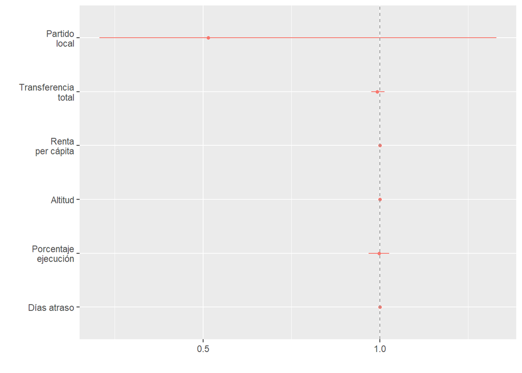

```r
library(ggplot2)
dotwhisker::dwplot(list(BinomialNegativa=rbn),exp=T) + scale_y_discrete(labels=c("Días atraso", "Porcentaje\nejecución", "Altitud", "Renta\nper cápita", "Transferencia\ntotal", "Partido\nlocal")) + scale_color_discrete(name="Modelos para:\nCantidad de Asegurados") + geom_vline(
           xintercept = 1,
           colour = "grey60",
           linetype = 2
       )
```

Como podemos apreciar, ninguna de nuestras variables resultan significativas.

# Distribución de protestas por tipo de partido (nacional - local)

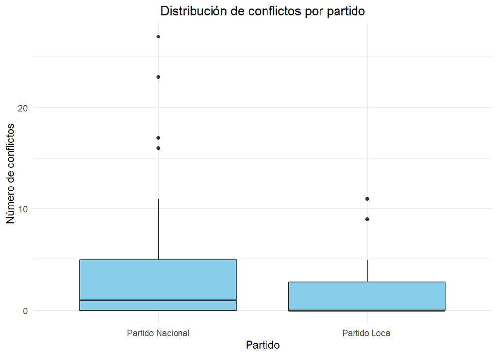

```r
ggplot(protestas, aes(x = PP_Nac_Loc, y = CONFLICTOS)) +
  geom_boxplot(fill = "skyblue") +
  scale_x_discrete(labels = c(
    "1" = "Partido Nacional",
    "2" = "Partido Local")) +
  labs(title = "Distribución de conflictos por partido",
       x = "Partido",
       y = "Número de conflictos") +
  theme_minimal()+
  theme(plot.title = element_text(hjust = 0.5))
```

¿Y cómo se distribuye el tipo de partido en todos los distritos?

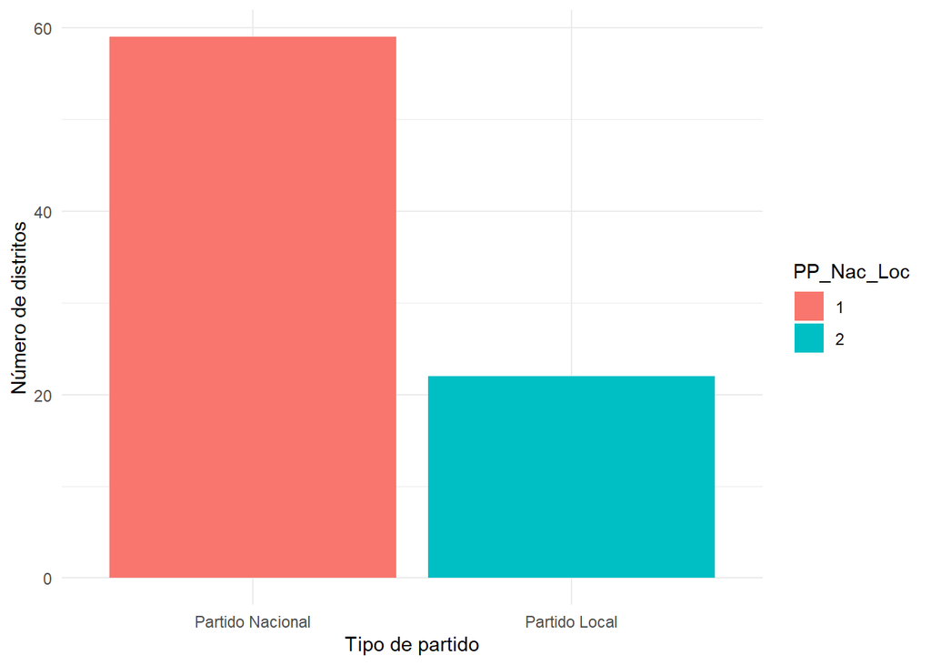

```r
library(ggplot2)
library(dplyr)

protestas %>%
  count(PP_Nac_Loc) %>%
  ggplot(aes(x= PP_Nac_Loc, y = n, fill = PP_Nac_Loc)) +
  geom_col() +
  scale_x_discrete(labels = c(
    "1" = "Partido Nacional",
    "2" = "Partido Local")) +
  labs(tittle= "Distribución de distritos por tipo de partido",
       x = "Tipo de partido",
       y = "Número de distritos") +
  theme_minimal()
```